# Transformation

Making abundances comparable and analysable

Monday, September 28, 2026

## Microbiome data

- **High variability**: feature abundances vary widely across samples
- **Zero-inflation**: many taxa absent in most samples
- **Compositionality**: only relative abundances observed; total counts per sample are arbitrary

## Heteroscedasticity

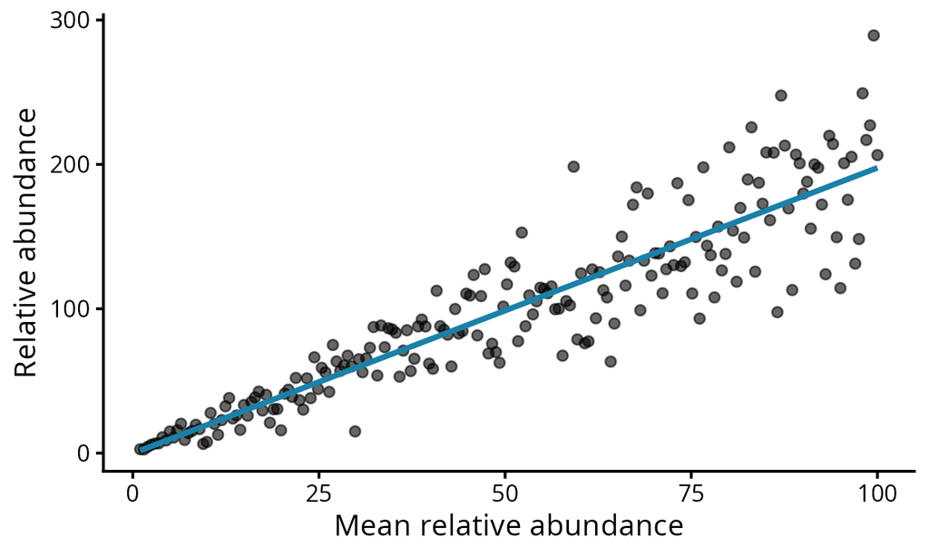

## Zero-inflation

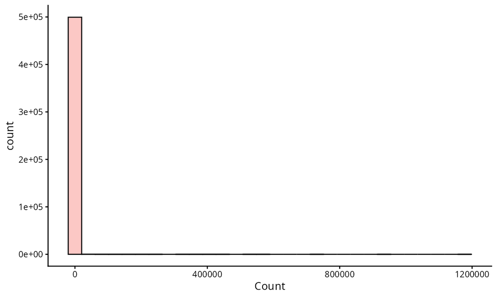

## Compositionality

- Sequencing measures **relative abundances**, not true microbial counts
- Values are **parts of a whole**
- Parts are **linked by a fixed total** (library size)
  - If one increases, at least one other must decrease

## Absolute versus relative

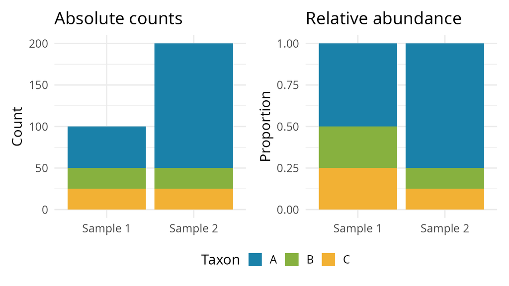

## Relative vs. quantitative profiles

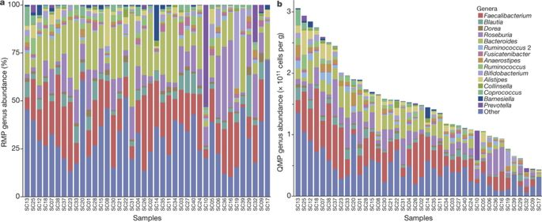

RMP / QMP: relative / quantitative microbiome profiling. Vandeputte et al. (2017)

## RMP vs. QMP: conclusions can flip

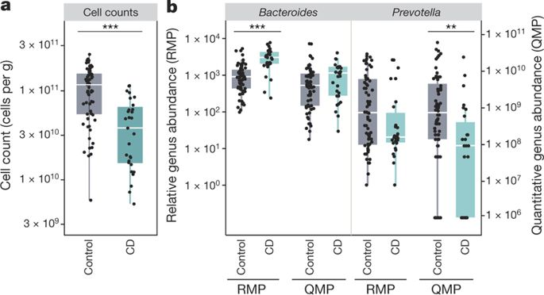

Vandeputte et al. (2017)

## Compositionality is not optional

> “… microbiome datasets generated by HTS are compositional because they have an arbitrary total imposed by the instrument.”

> “… HTS datasets derived from microbiome studies can and should be treated as compositions at all stages of analysis.”

Gloor et al. (2017), *Microbiome datasets are compositional: and this is not optional*

## Goals of transformation

- Mitigate biases in abundances
- Make features comparable across samples
- Meet assumptions of downstream statistical analyses

## Relative abundance

> *Library sizes are arbitrary*

$$\text{X}_{ij} = \frac{\text{Count}_{ij}}{\sum_{k=1}^m \text{Count}_{ik}}$$

*where*

- $i$ indexes the sample,
- $j$ indexes the taxon,
- $m$ is the total number of taxa.

## Log-transformed relative abundance

> *Library sizes are arbitrary and data zero-inflated*

$$\text{X}_{ij} = \log \left( \text{Relative abundance}_{ij} + \epsilon \right)$$

*where*

- $\epsilon$ is a small pseudocount to avoid $\log(0)$.

## Counts, proportions, logs

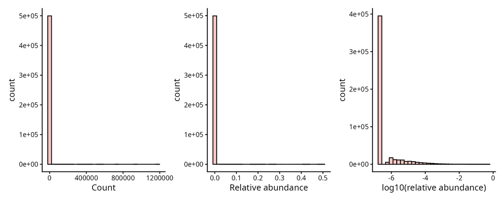

## Centered log-ratio (CLR)

> *Library sizes are arbitrary and values are dependent*

$$\text{CLR}(x_i) = \log\left(\frac{x_i}{g(x)}\right),\quad
g(x) = \left(\prod_{j=1}^{D} x_j \right)^{1/D}$$

- $x_i$: abundance of bacteria $i$
- $g(x)$: geometric mean across all bacteria in the sample

## Intuition

1. Values dependent, only ratios matter

## Intuition

1. Values dependent, only ratios matter
2. Standard statistics rely on subtraction and distance

## Intuition

1. Values dependent, only ratios matter
2. Standard statistics rely on subtraction and distance

$$\frac{x}{y} \;\longrightarrow\; a - b \;?$$

## Intuition

1. Values dependent, only ratios matter
2. Standard statistics rely on subtraction and distance
   - Use log-scale

$$\log\left(\frac{x}{y}\right) = \log(x) - \log(y)$$

## Intuition

1. Values dependent, only ratios matter
2. Standard statistics rely on subtraction and distance
   - Use log-scale
3. Library sizes are arbitrary

## Intuition

1. Values dependent, only ratios matter
2. Standard statistics rely on subtraction and distance
   - Use log-scale
3. Library sizes are arbitrary
   - Center the data

## Centering

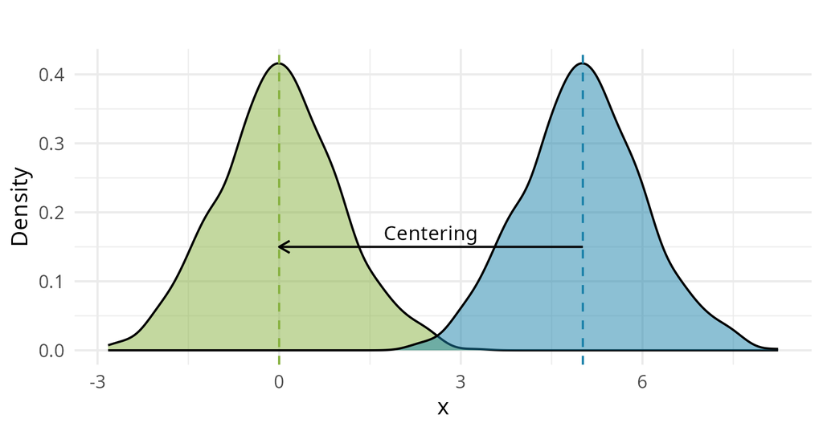

## Centering the logs

$$\begin{aligned}
\text{CLR}(x_i) &= \log\left(\frac{x_i}{g(x)}\right) \\[2mm]
&= \log(x_i) - \log(g(x))
\end{aligned}$$

## Why the geometric mean?

$$\text{Arithmetic mean} = \frac{2 + 8 + 32}{3} = \frac{42}{3} = 14$$

$$\begin{aligned}
\text{Geometric mean} &= \sqrt[3]{2 \cdot 8 \cdot 32} \\[2mm]
&= \exp\left( \frac{\log 2 + \log 8 + \log 32}{3} \right) \\[2mm]
&= 8
\end{aligned}$$

## Intuition: summary

1. Values dependent, only ratios matter
2. Standard statistics rely on subtraction and distance
   - Use log-scale
3. Library sizes are arbitrary
   - Center the data

## Centered log-ratio (CLR)

$$\begin{aligned}
\text{CLR}(x_i) &= \log\left(\frac{x_i}{g(x)}\right) \\[2mm]
&= \log(x_i) - \log(g(x)) \\[2mm]
&= \log(x_i) - \frac{1}{D}\sum_{j=1}^{D}\log(x_j)
\end{aligned}$$

## Counts versus CLR

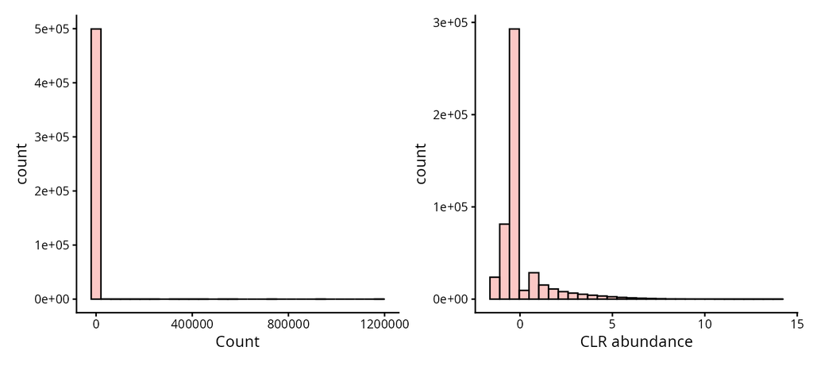

## Correct transformation depends on

1. Your research question
2. The analysis method

> *Use the simplest justified approach that works*

## Demonstration

```r
library(mia)
data("GlobalPatterns", package = "mia")
tse <- GlobalPatterns

tse <- transformAssay(tse, method = "relabundance")
tse <- transformAssay(tse, method = "clr", pseudocount = TRUE)
assayNames(tse)
```

```
[1] "counts"       "relabundance" "clr"
```

## Exercises

**OMA online book, Chapter 12: Transformation**

[microbiome.github.io/OMA › Transformation](https://microbiome.github.io/OMA/docs/devel/pages/transformation.html)

**All exercises**

## References

Gloor, Gregory B., Jean M. Macklaim, Vera Pawlowsky-Glahn, and Juan J. Egozcue. 2017. “Microbiome Datasets Are Compositional: And This Is Not Optional.” *Frontiers in Microbiology* 8: 2224. https://doi.org/10.3389/fmicb.2017.02224.

Vandeputte, Doris, Gunter Kathagen, Kevin D’hoe, Sara Vieira-Silva, Mireia Valles-Colomer, João Sabino, Jun Wang, et al. 2017. “Quantitative Microbiome Profiling Links Gut Community Variation to Microbial Load.” *Nature* 551 (7681): 507–11. https://doi.org/10.1038/nature24460.